# Notebook for Data Analyses of Chinese Samples in Psychological Subjects [Stage 1 RR]

# Load data and preprocess the data

Now, because Jones et al.(201)’ data is needed for the next part (Re-addressing the age bin issue), let’s load and preprocess the data first.

```r
load("df_chinese_subj_rr_stage1.RData")
```

```r
df_census6_age <- df_census6 %>%
  dplyr::select(1,3,4) %>%
  dplyr::rename(ageBins=1,
                male=2,
                female=3) %>%
  dplyr::mutate_at(c("ageBins","male","female"),as.numeric) %>%
  na.omit() %>%
  dplyr::add_row(ageBins=100,
                 male=8852,
                 female=27082) %>%  ###100 represent 100 years old and above
  tidyr::pivot_longer(-ageBins,names_to = "sex",values_to = "num")

df_census7_age <- df_census7 %>%
  dplyr::select(1,3,4) %>%
  dplyr::rename(ageBins=1,
                male=2,
                female=3) %>%
  dplyr::mutate_at(c("ageBins","male","female"),as.numeric) %>%
  na.omit() %>%
  dplyr::add_row(ageBins=100,
                 male=35129,
                 female=83737) %>% ###100 represent 100 years old and above
  tidyr::pivot_longer(-ageBins,names_to = "sex",values_to = "num")
```

## Re-addressing the age bin issue

This time, we tried to conduct a simulation using the logic as we generate age count data from the mean and SD data extracted from papers.

The simulation will use N as 1200 so that it will reveal the sensitivity of the sample size that resulted from sex ratio data.

```r
## First, we get a reasonable  mean age range by using PSA 001's data

# We used the bootstrap method to get the mean and 95% CI of the age

# We also used the bootstrap method to get the mean of SD and the distribution of SD


# get the SD of age from PSA001
df_PSA001_CN_SD <- df_PSA001 %>%
  dplyr::filter(Countries == "CHN") %>%
  dplyr::summarise(SD = sd(Age)) %>%
  dplyr::pull(SD)

df_PSA001_CN_M <- df_PSA001 %>%
  dplyr::filter(Countries == "CHN") %>%
  dplyr::summarise(M = mean(Age)) %>%
  dplyr::pull(M)

Sim_Sens_mult <- function(Mean1, diff_age, SD1, SD2, sampe_N=1200){

  # get the mean of difference
  Mean2 <- Mean1 + diff_age

  # Generate data with N = 1200
  # 0~17, 18~25, 26~40, 41~60, 61~
  ageData1 <- round((pnorm(c(18,26,41,61), mean = Mean1, sd =SD1) * sampe_N))
  ageData2 <- round((pnorm(c(18,26,41,61), mean = Mean2, sd =SD2) * sampe_N))

    # create a dataframe with ageData1 and ageData2:
  sim_age_df <- setNames(data.frame(matrix(ncol = 3, nrow = 5)), c("ageBins", "sim1", "sim2"))
  sim_age_df$ageBins <- c("<=17", "18~25", "26~40", "41~60", ">=61")
  sim_age_df$sim1[0:4] <- ageData1
  sim_age_df$sim2[0:4] <- ageData2

  # create a dataframe with ageData1 and ageData2:
  sim_age_df <- setNames(data.frame(matrix(ncol = 3, nrow = 5)), c("ageBins", "sim1", "sim2"))
  sim_age_df$ageBins <- c("<=17", "18~25", "26~40", "41~60", ">=61")
  sim_age_df$sim1[0:4] <- ageData1
  sim_age_df$sim2[0:4] <- ageData2

  sim_age_df <- sim_age_df %>%
    dplyr::mutate(sim1_new = sim1 - lag(sim1),
                  sim1_new = ifelse(is.na(sim1_new), sim1, sim1_new),
                  sim2_new = sim2 - lag(sim2),
                  sim2_new = ifelse(is.na(sim2_new), sim2, sim2_new),
                  # fill NA and zeros with 1 to avoid the error for Bayesian multinomial test
                  sim1_new = ifelse((is.na(sim1_new) | sim1_new == 0), 1, sim1_new),
                  sim2_new = ifelse((is.na(sim2_new) | sim2_new == 0), 1, sim2_new),
                  ageBins = factor(ageBins, levels = c("<=17", "18~25", "26~40", "41~60", ">=61"))) %>%
    dplyr::select(ageBins, sim1_new, sim2_new) %>%
    dplyr::rename(obs = sim1_new,
                  expected = sim2_new)

  tmp_BF <- BayesMultiNomial(sim_age_df,
                              factor = 'ageBins',
                              observed = 'obs',
                              expected = 'expected')

  # res <- c(tmp_BF$BF$BF10, tmp_BF$LogBF10)
  return(tmp_BF)
}

tmp <- Sim_Sens_mult(Mean1=df_PSA001_CN_M,
              diff_age=0,
              SD1=df_PSA001_CN_SD,
              SD2=df_PSA001_CN_SD,
              sampe_N=1200)

## record results
sim_age_diff <- seq(0, 2, 0.05)

rm('sim_MNtest')
sim_MNtest <- data.frame(matrix(nrow = length(sim_age_diff), ncol = 3))
colnames(sim_MNtest) <- c("ageDiff","BF10", "LogBF10")

for (kk in (seq(length(sim_age_diff)))){
  tmp_BF <- Sim_Sens_mult(Mean1=df_PSA001_CN_M,
                          diff_age=sim_age_diff[kk],
                          SD1=df_PSA001_CN_SD,
                          SD2=df_PSA001_CN_SD,
                          sampe_N=1200)
  sim_MNtest$ageDiff[kk] <- sim_age_diff[kk]
  sim_MNtest$BF10[kk] <- tmp_BF$BF$BF10
  sim_MNtest$LogBF10[kk] <- tmp_BF$BF$LogBF10
}

sim_MNtest %>%
  ggplot2::ggplot(aes(x = ageDiff, y = LogBF10)) +
  ggplot2::geom_point() +
  ggplot2::geom_hline(yintercept = c(log(6), log(1/6))) +
  ggplot2::theme_classic()
```

[output not shown]

# Test three hypotheses

## Test the 1st hypothesis

*This can only be done after collecting data.*

## Testing the 2nd hypothesis

Here we will test whether the sex ratio and age distribution from Chinese psychological studies are similar to that of the census data. As a comparison, we also compared that data from sociology, CFPS 2018, to the census data too. We use Bayesian multinomial test (Bayesian goodness-of-fit test) to examine whether the observed (Chinese psychological samples) fit the expected (7th Census data).

$H_0$: $\theta = c$, where $c$ is defined by census data or CFPS 2018; $H_1$: $\theta$ is free to vary.

### Sex distribution

```r
df_PSA001_sex_CN <- df_PSA001 %>%
  dplyr::filter(Countries == "CHN") %>%
  dplyr::count(Sex) %>%
  dplyr::mutate(Proportion = round(n / sum(n), 2) * 100,
                Site = "PSA001",
                Sex = ifelse(Sex == "f", 'female', 'male' )) %>%
  dplyr::select(Site, Sex, Proportion)

df_census7_sex <- df_census7 %>%
  dplyr::select(c(6,7)) %>%
  dplyr::slice(c(6)) %>%
  dplyr::rename(male=1,
                female=2) %>%
  dplyr::mutate(Site = "Census7") %>%
  tidyr::pivot_longer(c(male, female),
                      names_to = "Sex",
                      values_to = "Proportion") %>%
  dplyr::mutate(Proportion = round(as.numeric(Proportion), 0))

df_CFPS2018_sex <- df_CFPS2018 %>%
  dplyr::rename(Sex = QA002) %>%
  dplyr::count(Sex) %>%
  dplyr::filter(!is.na(Sex)) %>%
  dplyr::mutate(Proportion = round(n / sum(n), 2) * 100,
                Site = "CFPS2018",
                Sex = ifelse(Sex == 1, "male", "female")) %>%
  dplyr::select(Site, Sex, Proportion)

df_sex_ratio <- rbind(df_census7_sex, df_CFPS2018_sex, df_PSA001_sex_CN)

### get the data for Bayesian mutlinomial test as in JASP
df_sex_ratio_jasp <- df_sex_ratio %>%
  tidyr::pivot_wider(names_from = Site,
                     values_from = Proportion)
## save to csv
write.csv(df_sex_ratio_jasp, "df_sex_ratio_jasp.csv", row.names=FALSE)

BF_h2a_sex_psych <- BayesMultiNomial(dataset = df_sex_ratio_jasp, factor = "Sex", observed = "PSA001", expected = "Census7")
BF_h2a_sex_cfps <- BayesMultiNomial(dataset = df_sex_ratio_jasp, factor = "Sex", observed = "CFPS2018", expected = "Census7")

fig3a <- ggplot(df_sex_ratio, aes(Site, Proportion,fill=Sex)) +
  geom_col() +
  theme_classic()+
  xlab("Data sources") +
  theme(legend.position = "bottom",
        legend.key.size = unit(20,"pt"),
        legend.box.spacing = unit(4,"pt"),
        legend.title = element_blank(),
        axis.title = element_text(size = 16, family = "serif"),
        legend.text = element_text(size = 16, family = "serif"),
        axis.text = element_text(size =16, family = "serif"))
#fig3a
```

We found strong evidence for the $H_1$ that the sex ratio from PSA001 is different from that of Census data, with $Log(BF_{10})$ = 3.7333804. On the contrast, for the CFPS data, we found moderate evidence for the $H_0$ that sex ratio from CFPS2018 is not different from that of Census data, $Log(BF_{10})$ = -2.0642401

### Age distribution

Here we will compare the age distribution of samples from psychological studies (PSA 001 as the example) and the Census data.

First, we define a function to segment the agebins of census.

```r
Func_census_Age_Prop <- function(df_census, break_names, label_names,level_names,wider_form=TRUE){

  # function for calculating the proportion of age bins based on the break_names and label_names
  # df: the input data, with ageBins,male, female,and site
  # break_names, a vector of number
  # label_names, a vector of string
  # level_names, a factor
  #
  # return a wide-format data frame for further BF calculation

  df_tmp_census <- df_census %>%
    dplyr::mutate(ageBins=cut(ageBins,
                              breaks=break_names,
                              labels=label_names)) %>%
    group_by(ageBins,sex) %>%
    summarise(num=sum(num)) %>%
    ungroup() %>%
    dplyr::mutate(freq=(num/sum(num))*100) %>%
    dplyr::mutate(percent = floor(freq),
                  indx = freq - percent,
                  site="census7")

  df_tmp_census$ageBins= factor(df_tmp_census$ageBins,levels=level_names)

  ## below we fill the percentage to 100%

  filler_idx_census <- df_tmp_census %>%
    dplyr::group_by(site) %>%
    dplyr::summarise(sum = sum(percent)) %>%
    dplyr::ungroup()

  df_tmp_filled_census <- data.frame(matrix(ncol = ncol(df_tmp_census), nrow = 0))
  colnames(df_tmp_filled_census) <- colnames(df_tmp_census)

  for (ii in 1:nrow(filler_idx_census)){
    tmp_census <- df_tmp_census %>%
      dplyr::filter(site == filler_idx_census$site[ii]) %>%
      dplyr::arrange(desc(indx))

    if (filler_idx_census$sum[ii] < 100) {
      for (jj in seq(100 - filler_idx_census$sum[ii])){
        tmp_census$percent[jj] <- tmp_census$percent[jj] + 1
      }
    }
    df_tmp_filled_census <- rbind(df_tmp_filled_census, tmp_census)
  }

  df_tmp_filled_census <- df_tmp_filled_census %>%
    dplyr::arrange(ageBins, sex)

  if (wider_form){
    df_tmp_filled_census <- df_tmp_filled_census %>%
      dplyr::select(-c(num, freq, indx)) %>%
      tidyr::pivot_wider(names_from = "ageBins", values_from = "percent")
  }

  return(df_tmp_filled_census)
}
```

Next, we cotinue to defining a function to segment the agebins of pPSA001.

```r
Func_PSA001_Age_Prop <- function(df_PSA, break_names, label_names, level_names,wider_form=TRUE){

  # function for calculating the proportion of age bins based on the break_names and label_names
  # df: the input data, with user_id, Countries, Sex, and Age
  # break_names, a vector of number
  # label_names, a vector of string
  # level_names, a factor
  #
  # return a wide-format data frame for further BF calculation

  df_tmp_PSA <- df_PSA %>%
    dplyr::select(user_id, Countries, Sex, Age) %>%
    dplyr::filter(Countries=="CHN") %>%
    dplyr::mutate(ageBins_pyr=cut(Age,
                              breaks=break_names,
                              labels=label_names)) %>%
    dplyr::count(ageBins_pyr, Sex) %>%
    dplyr::mutate(freq = (n / sum(n))*100) %>%
    tidyr::complete(ageBins_pyr, Sex,fill = list(n = 0, freq = 0)) %>%
    dplyr::mutate(percent = floor(freq),
                  indx = freq - percent) %>%
    dplyr::mutate(site="PSA001",
                  Sex=ifelse(Sex=="f","female_PSA","male_PSA"))


  df_tmp_PSA$ageBins_pyr= factor(df_tmp_PSA$ageBins_pyr,levels=level_names)

  ## below we fill the percentage to 100%

  filler_idx_PSA <- df_tmp_PSA %>%
    dplyr::group_by(site) %>%
    dplyr::summarise(sum = sum(percent)) %>%
    dplyr::ungroup()

  df_tmp_filled_PSA <- data.frame(matrix(ncol = ncol(df_tmp_PSA), nrow = 0))
  colnames(df_tmp_filled_PSA) <- colnames(df_tmp_PSA)

  for (ii in 1:nrow(filler_idx_PSA)){
    tmp_PSA <- df_tmp_PSA %>%
      dplyr::filter(site == filler_idx_PSA$site[ii]) %>%
      dplyr::arrange(desc(indx))

    if (filler_idx_PSA$sum[ii] < 100) {
      for (jj in seq(100 - filler_idx_PSA$sum[ii])){
       tmp_PSA$percent[jj] <- tmp_PSA$percent[jj] + 1
      }
    }
    df_tmp_filled_PSA <- rbind(df_tmp_filled_PSA, tmp_PSA)
  }
  df_tmp_filled_PSA <- df_tmp_filled_PSA %>%
    dplyr::arrange(ageBins_pyr,Sex)

  if (wider_form){
    df_tmp_filled_PSA <- df_tmp_filled_PSA %>%
      dplyr::select(-c(n, freq, indx)) %>%
      tidyr::pivot_wider(names_from = "ageBins_pyr", values_from = "percent")
  }


  return(df_tmp_filled_PSA)
}
```

#### Age bins [set 1]: demogrphic age bins

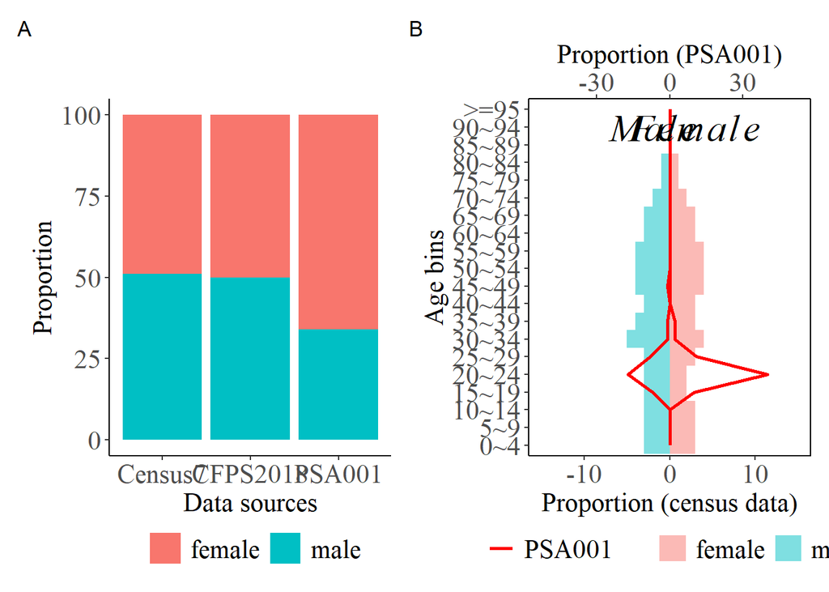

```r
df_PSA001_Age_CN <- Func_PSA001_Age_Prop(df_PSA001,
                                         break_names =c(-Inf,4.5,9.5,14.5,19.5,24.5,
                                                        29.5,34.5,39.5,44.5,49.5,
                                                        54.5,59.5,64.5,69.5,74.5,
                                                        79.5,84.5,89.5,94.5,Inf),
                                         label_names = c("0~4","5~9","10~14","15~19","20~24",
                                     "25~29","30~34","35~39","40~44","45~49",
                                     "50~54","55~59","60~64","65~69","70~74",
                                     "75~79","80~84","85~89", "90~94",">=95"),
                                     level_names = c("0~4","5~9","10~14","15~19","20~24",
                                     "25~29","30~34","35~39","40~44","45~49",
                                     "50~54","55~59","60~64","65~69","70~74",
                                     "75~79","80~84","85~89", "90~94",">=95"),
                     wider_form = FALSE)

df_census7_age_new <- Func_census_Age_Prop(df_census7_age,
                     break_names = c(-Inf,4.5,9.5,14.5,19.5,24.5,
                                     29.5,34.5,39.5,44.5,49.5,
                                     54.5,59.5,64.5,69.5,74.5,
                                      79.5,84.5,89.5,94.5,Inf),
                     label_names = c("0~4","5~9","10~14","15~19","20~24",
                                     "25~29","30~34","35~39","40~44","45~49",
                                     "50~54","55~59","60~64","65~69","70~74",
                                     "75~79","80~84","85~89", "90~94",">=95"),
                     level_names = c("0~4","5~9","10~14","15~19","20~24",
                                     "25~29","30~34","35~39","40~44","45~49",
                                     "50~54","55~59","60~64","65~69","70~74",
                                     "75~79","80~84","85~89", "90~94",">=95"),
                     wider_form = FALSE)

fig3b <- ggplot(data= df_census7_age_new, aes(x=ageBins, y=ifelse(sex=="male", -percent, percent), fill=sex)) +
  geom_col(alpha=0.5, width = 1) +
  geom_line(data = df_PSA001_Age_CN, aes(x=ageBins_pyr,
                                      y = ifelse(Sex == "male_PSA", -percent/3.5, percent/3.5),
                                      group=Sex,color="PSA001"), size=1, inherit.aes = FALSE) +
  scale_y_continuous(limits = c(-15,15),sec.axis = sec_axis(~.*3.5, name = "Proportion (PSA001)")) +
  coord_flip() +
  labs(y="Proportion (census data)", x = "Age bins", color=NULL)+
  annotate("text",label= "italic(Male)",x=19,y=-2,parse=TRUE,size=8, family = "serif") +
  annotate("text",label= "italic(Female)",x=19,y=3,parse=TRUE,size=8,family = "serif") +
  scale_color_manual(values = c("red","blue"))+
  theme_classic()+
  theme(panel.border =element_rect(fill=NA,color="black"),
        legend.position ="bottom",
        legend.box.spacing = unit(2,"pt"),
        legend.text = element_text(size = 16, family = "serif"),
        legend.title = element_blank(),
        axis.title = element_text(size = 16,family = "serif"),
        axis.text = element_text(size = 16,family = "serif"))

fig3 <- fig3a + fig3b +  plot_annotation(tag_levels = 'A')
ggsave("fig3.pdf", fig3, device = "pdf", width=16, height = 9)

fig3
```

Also get the data for Bayesian multinomial test.

```r
### PAS001' age is divided into ten years
df_PSA001_Age_CN_jasp_interval10 <- Func_PSA001_Age_Prop(df_PSA001,
                                                          break_names = c(0, 9.5, 19.5, 29.5, 30.5, 40.5, 59.5, Inf),
                                                          label_names = c("0~9","10~19","20~29", "30~39", "40~49", "50~59", ">=60"),
                                                          level_names = c("0~9","10~19","20~29", "30~39", "40~49", "50~59", ">=60"),
                                                          wider_form = FALSE) %>%
  dplyr::group_by(ageBins_pyr) %>%
  dplyr::summarise(percent=sum(percent)) %>%
  dplyr::ungroup() %>%
  dplyr::rename(PSA001_CN=percent,
                ageBins=ageBins_pyr)


### PSA001' age is divided into stages of development
df_PSA001_Age_CN_Jasp_interval_stages <- Func_PSA001_Age_Prop(df_PSA001,
                                                              break_names = c(0, 17.5, 25.5, 40.5, 59.5, Inf),
                                                              label_names = c("0~17","18~25","26~40", "41~59", ">=60"),
                                                              level_names = c("0~17","18~25","26~40", "41~59", ">=60"),
                                                              wider_form = FALSE) %>%
  dplyr::group_by(ageBins_pyr) %>%
  dplyr::summarise(percent=sum(percent)) %>%
  dplyr::ungroup() %>%
  dplyr::rename(PSA001_CN=percent,
                ageBins=ageBins_pyr)


###Census7' age is divided into ten years
df_census7_age_jasp_interval10 <- Func_census_Age_Prop(df_census7_age,
                                                       break_names = c(-Inf, 9.5, 19.5, 29.5, 30.5, 40.5, 59.5, Inf),
                                                       label_names = c("0~9","10~19","20~29", "30~39", "40~49", "50~59", ">=60"),
                                                       level_names = c("0~9","10~19","20~29", "30~39", "40~49", "50~59", ">=60"),
                                                       wider_form = FALSE) %>%
  dplyr::group_by(ageBins) %>%
  dplyr::summarise(percent=sum(percent)) %>%
  dplyr::ungroup() %>%
  dplyr::rename(Census7=percent)


###Census' age is divided into the stages of development
df_census7_age_jasp_interval_stages <- Func_census_Age_Prop(df_census7_age,
                                                       break_names = c(-Inf, 17.5, 25.5, 40.5, 59.5, Inf),
                                                       label_names = c("0~17","18~25","26~40", "41~59", ">=60"),
                                                       level_names = c("0~17","18~25","26~40", "41~59", ">=60"),
                                                       wider_form = FALSE) %>%
  dplyr::group_by(ageBins) %>%
  dplyr::summarise(percent=sum(percent)) %>%
  dplyr::ungroup() %>%
  dplyr::rename(Census7=percent)


df_age_jasp_interval10 <- df_PSA001_Age_CN_jasp_interval10 %>%
  dplyr::left_join(.,df_census7_age_jasp_interval10)

df_age_jasp_interval_stages <- df_PSA001_Age_CN_Jasp_interval_stages %>%
  dplyr::left_join(.,df_census7_age_jasp_interval_stages)


# save the CSV to compare the BayesMultiNomial with the result in JASP
write.csv(df_age_jasp_interval_stages, "df_age_jasp_interval_stages.csv", row.names = FALSE)

write.csv(df_age_jasp_interval10, "df_age_jasp_interval10.csv", row.names = FALSE)

BF_h2b_age_psych_interval10 <- BayesMultiNomial(dataset = df_age_jasp_interval10,
                                     factor = "ageBins",
                                     observed = "PSA001_CN",
                                     expected = "Census7")

BF_h2b_age_psych_interval_stages <- BayesMultiNomial(dataset = df_age_jasp_interval_stages,
                                                     factor = "ageBins",
                                                     observed = "PSA001_CN",
                                                     expected = "Census7")
```

#### Age bins [set 2]: Psychological age bins

## Test H3: Chinese samples versus samples from other countries

We first select data for plotting.

```r
### Get countries with n >=30
PSA001_valid_countries <-  df_PSA001 %>%
  dplyr::group_by(Countries) %>%
  dplyr::summarise(n = n()) %>%
  dplyr::ungroup() %>%
  dplyr::filter(n >=30 & !is.na(Countries)) %>%
  dplyr::pull(Countries)

### remove data without sex info
df_PSA001_valid_sex <-  df_PSA001 %>%
  dplyr::filter(Countries %in% PSA001_valid_countries)


df_PSA001_valid_merge <- merge(df_PSA001_valid_sex, df_regionCode, by.x = "Countries", by.y = "Jones_country")

df_PSA001_valid_merge_sex_ratio <- df_PSA001_valid_merge %>%
  dplyr::count(weird, Countries, Sex) %>%
  dplyr::group_by(weird, Countries) %>%
  dplyr::mutate(Proportion = round(n / sum(n), 2)) %>%
  dplyr::arrange(Sex, Proportion) %>%
  dplyr::ungroup()

countries_order_sex <- df_PSA001_valid_merge_sex_ratio %>%
  dplyr::filter(Sex == "f") %>%
  dplyr::pull(Countries)

df_PSA001_valid_merge_sex_ratio_sorted <- df_PSA001_valid_merge_sex_ratio %>%
  dplyr::mutate(Countries = factor(Countries, levels = countries_order_sex))

df_PSA001_valid_merge_sex_ratio_sorted_wide <- df_PSA001_valid_merge_sex_ratio_sorted %>%
  dplyr::select(-c(weird,n)) %>%
  dplyr::mutate(Proportion = Proportion * 100)  %>%
  tidyr::pivot_wider(names_from = "Countries", values_from = "Proportion")
```

Then, we define a function for calculating BF for multiple countries.

```r
# create a new variable to store the BF values
Func_BFpairs <- function(df, countries_order, prop_name){

  # create a temp variable for storing
  BF_mult_tmp <- data.frame(matrix(nrow = 0, ncol = 5))
  colnames(BF_mult_tmp) <- c("Observed", "Expected", "Log(BF10)_NonInform", "BF10_NonInform", "BF01_NonInform")

  for (ii in seq(length(countries_order))){
    country <- countries_order[ii]
    if (country != "CHN"){
      df_tmp <- df %>% dplyr::select(prop_name, one_of(country), "CHN")

      BF_tmp <- BayesMultiNomial(dataset = df_tmp,
                                 factor = prop_name, observed = country, expected = "CHN")

      BF_mult_tmp[ii,] <- c(country, "CHN", BF_tmp$BF$LogBF10, BF_tmp$BF$BF10, BF_tmp$BF$BF01)
    }
  }

  countries_order_age <- BF_mult_tmp %>%
    tidyr::drop_na() %>%
    dplyr::mutate(`Log(BF10)_NonInform` = as.numeric(`Log(BF10)_NonInform`)) %>%
    dplyr::arrange(`Log(BF10)_NonInform`) %>%
    dplyr::pull(Observed)

  BF_mult_p_tmp <- BF_mult_tmp %>%
    tidyr::drop_na() %>%
    dplyr::select(1,2,3) %>%
    dplyr::mutate(Contries = factor(Observed, levels = countries_order_age),
                  `Log(BF10)_NonInform` = as.numeric(`Log(BF10)_NonInform`))

  return(BF_mult_p_tmp)
}
```

Then,we calculating BF and plotting figure 4a.

```r
# compare each country with CN, non-informative prior
BF_h3a_sex_p <- Func_BFpairs(df = df_PSA001_valid_merge_sex_ratio_sorted_wide,
                             countries_order = countries_order_sex,
                             prop_name = "Sex")

fig4a <- ggplot(BF_h3a_sex_p, aes( x = `Log(BF10)_NonInform`, y = Contries)) +
  geom_point() +
  scale_color_grey() +
  xlim(-3, 21) +
  scale_y_discrete(limits=rev) +
  geom_vline(xintercept = c(log(1/10), log(1/6), 0, log(6), log(10)),
             colour = c("red", "tomato", "black", "deepskyblue","blue"),
             linetype=c("longdash", "longdash", "solid", "longdash","longdash")) +
  geom_text(aes(x=log(10), label="\nStrong evidence for H1", y = 23), colour="blue", alpha = 0.7,
            angle=90, text=element_text(size=10)) +
  geom_text(aes(x=log(6), label="Moderate evidence for H1\n", y = 23), colour="deepskyblue", alpha = 0.7,
            angle=90, text=element_text(size=10)) +
  geom_text(aes(x=log(1/6), label="\nModerate evidence for H0", y = 23), colour="tomato", alpha = 0.7,
            angle=90, text=element_text(size=10)) +
  geom_text(aes(x=log(1/10), label="Strong evidence for H0\n", y = 23), colour="red", alpha = 0.7,
            angle=90, text=element_text(size=10)) +
  ggtitle("Sex ratio") +
  xlab("Log(BF10)")+
  theme_bw() +
        theme(panel.grid.major = element_blank(),
              panel.grid.minor = element_blank(),
              panel.background = element_blank(),
              panel.border = element_blank(),
              text = element_text(family='Times'),
              axis.text.x = element_text (size = 14, color = 'black',  hjust = 1),
              axis.text.y = element_text (size = 16, color = 'black'),
              plot.title = element_text(lineheight=.8, face="bold", size = 18, margin=margin(0,0,20,0)),
              axis.text = element_text (size = 16, color = 'black'),
              axis.title = element_text (size = 16),
              axis.title.x = element_text (size = 16),
              axis.title.y = element_text( size = 16),
              axis.line.x = element_line(color='black', size = 1),
              axis.line.y = element_line(color='black', size = 1))
#fig4a
```

Plotting figure 4c.

```r
fig4c <- ggplot(df_PSA001_valid_merge_sex_ratio_sorted, aes(x=Proportion, y=Countries,fill=Sex)) +
  geom_col(alpha = .75)+
  labs(y="Countries") +
  scale_fill_discrete(label=c("female","male")) +
  theme_classic()+
  guides(y="axis_nested") +
  theme(legend.title = element_text(size = 15,family = "serif"),
        axis.title= element_text(size = 15,family = "serif"),
        axis.text = element_text(size = 10,family = "serif"),
        strip.text = element_text(size = 15,family = "serif"),
        strip.background = element_rect(fill = NA,color = NA),
        panel.border = element_rect(fill = NA,color = "black")) +
  scale_x_continuous(breaks = seq(0, 1, by = 0.1)) +
  facet_wrap(~ weird, scales = "free")
#fig4c
```

Get the percentage of each age bin and save for Bayesian multinomial test. We found that if the expected proportion contains zero if may cause problem in the calculation, thus, we re-organized the data based on the proportion data of Chinese sample.

```r
Func_Age_Prop <- function(df, break_names, label_names, wider_form=TRUE){

  # function for calculating the proportion of age bins based on the break_names and label_names
  # df: the input data, with user_id, Countries, Sex, and Age
  # break_names, a vector of number
  # label_names, a vector of string
  #
  # return a wide-format data frame for further BF calculation

  df_tmp <- df %>%
    dplyr::select(user_id, Countries, Sex, Age) %>%
    dplyr::mutate(ageBins=cut(Age,
                              breaks=break_names,
                              labels=label_names)) %>%
    dplyr::count(Countries, ageBins) %>%
    dplyr::group_by(Countries) %>%
    dplyr::mutate(freq = (n / sum(n))*100) %>%
    dplyr::ungroup() %>%
    tidyr::complete(Countries, ageBins, fill = list(n = 0, freq = 0)) %>%
    dplyr::mutate(percent = floor(freq),
                  indx = freq - percent)

  ## below we fill the percentage to 100%

  filler_idx <- df_tmp %>%
    dplyr::group_by(Countries) %>%
    dplyr::summarise(sum = sum(percent)) %>%
    dplyr::ungroup()

  df_tmp_filled <- data.frame(matrix(ncol = ncol(df_tmp), nrow = 0))
  colnames(df_tmp_filled) <- colnames(df_tmp)

  for (ii in 1:nrow(filler_idx)){
    tmp <- df_tmp %>%
      dplyr::filter(Countries == filler_idx$Countries[ii]) %>%
      dplyr::arrange(desc(indx))

    if (filler_idx$sum[ii] < 100) {
      for (jj in seq(100 - filler_idx$sum[ii])){
       tmp$percent[jj] <- tmp$percent[jj] + 1
      }
    }
    df_tmp_filled <- rbind(df_tmp_filled, tmp)
  }
  df_tmp_filled <- df_tmp_filled %>%
    dplyr::arrange(Countries, ageBins)

  if (wider_form){
    df_tmp_filled <- df_tmp_filled %>%
      dplyr::select(-c(n, freq, indx)) %>%
      tidyr::pivot_wider(names_from = "Countries", values_from = "percent")
  }


  return(df_tmp_filled)
}
```

Process the age data of PSA001 for plotting figure 4d.

```r
df_PSA001_Age_valid <- df_PSA001 %>%
  dplyr::filter(Countries %in% PSA001_valid_countries)

# merge with country code and force the age over 60 in a narrow range for visualization
df_PSA001_Age_valid_countryCode <- merge(df_PSA001_Age_valid, df_regionCode, by.x = "Countries", by.y = "Jones_country") %>%
  dplyr::mutate(Age = ifelse(Age > 60, sample(c(61, 62, 63, 64, 65), 1), Age))

PSA001_valid_countries_sorted <- df_PSA001_Age_valid_countryCode %>%
  dplyr::group_by(Countries) %>%
  dplyr::summarise(medianAge = median(Age)) %>%
  dplyr::ungroup() %>%
  dplyr::arrange(medianAge) %>%
  dplyr::pull(Countries)

df_PSA001_Age_valid_countryCode_sorted <- df_PSA001_Age_valid_countryCode %>%
  dplyr::mutate(Countries = factor(Countries, levels = PSA001_valid_countries_sorted))

# age bin same as census data
df_PSA001_age_Jasp1 <- Func_Age_Prop(df = df_PSA001_Age_valid_countryCode_sorted,
                                     break_names = c(0, 10.5, 20.5, 30.5, 40.5, 50.5, 60.5, Inf),
                                     label_names = c("0~10","11~20","21~30", "31~40", "41~50", "51~60", ">=61"))

df_PSA001_age_Jasp1 <- df_PSA001_age_Jasp1 %>%
  # fill zero
  dplyr::mutate(CHN = ifelse(CHN==0, 1,
                            ifelse(CHN==38, 37,
                                   ifelse(CHN  == 55, 54, CHN))))

# age bin based on psychological aging stage
df_PSA001_age_Jasp2 <- Func_Age_Prop(df = df_PSA001_Age_valid_countryCode_sorted,
                                     break_names = c(0, 17.5, 25.5, 39.5, 59.5, Inf),
                                     label_names = c("0~17","18~25", "26~40", "41~59", ">=60"))

df_PSA001_age_Jasp2 <- df_PSA001_age_Jasp2 %>%
  # fill zero
  dplyr::mutate(CHN = ifelse(CHN==0, 1,
                            ifelse(CHN==80, 78, CHN)))

df_PSA001_age_Jasp2_long <- Func_Age_Prop(df = df_PSA001_Age_valid_countryCode_sorted,
                                     break_names = c(0, 17.5, 25.5, 39.5, 59.5, Inf),
                                     label_names = c("0~17","18~25", "26~40", "41~59", ">=60"),
                                     wider_form = FALSE) %>%
  dplyr::left_join(., df_regionCode, by = c("Countries" = "Jones_country")) %>%
  dplyr::mutate(Proportion = percent/100)

# Countries order for plotting age bins proportions
df_PSA001_age_Jasp2_long_countries <- df_PSA001_age_Jasp2_long %>%
  dplyr::filter(ageBins == "18~25") %>%
  dplyr::arrange(Proportion) %>%
  dplyr::pull(Countries)

df_PSA001_age_Jasp2_long <- df_PSA001_age_Jasp2_long %>%
  dplyr::mutate(Countries = factor(Countries, levels = df_PSA001_age_Jasp2_long_countries))
```

Plotting figure 4d.

```r
fig4d <- ggplot(df_PSA001_age_Jasp2_long, aes(x=Proportion, y=Countries, fill=ageBins)) +
  geom_col(alpha = .75)+
  labs(y="Countries") +
  scale_fill_discrete(label=c("0~17", "18~25", "26~40", "41~59",">=60" )) +
  theme_classic()+
  guides(y="axis_nested") +
  theme(legend.title = element_text(size = 15,family = "serif"),
        axis.title= element_text(size = 15,family = "serif"),
        axis.text = element_text(size = 10,family = "serif"),
        strip.text = element_text(size = 15,family = "serif"),
        strip.background = element_rect(fill = NA,color = NA),
        panel.border = element_rect(fill = NA,color = "black")) +
  scale_x_continuous(breaks = seq(0, 1, by = 0.1)) +
  facet_wrap(~ weird, scales = "free")
#fig4d
```

Plotting figure 4b.

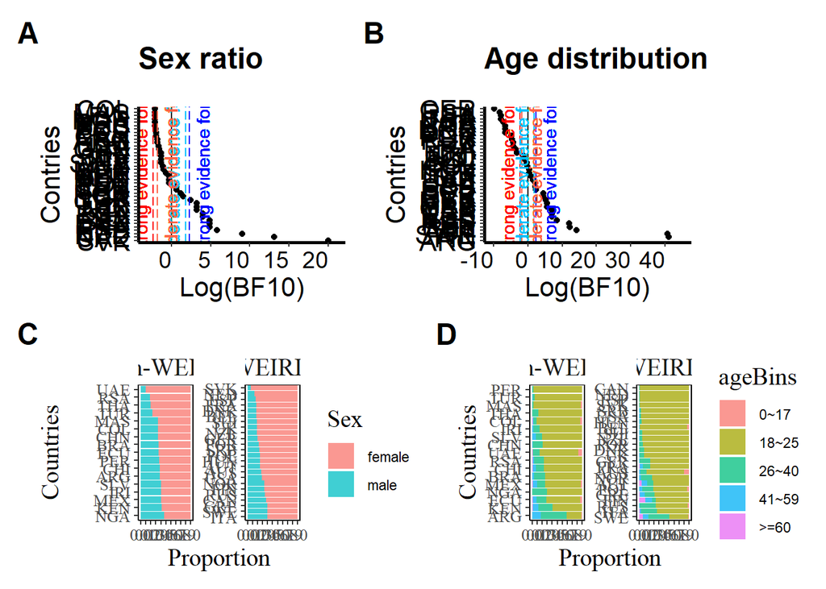

```r
# BF for age bins 0, NA for informed prior because of zeros in the dataframe
BF_h3b_age_p_1 <- Func_BFpairs(df = df_PSA001_age_Jasp1,
                             countries_order = countries_order_sex,
                             prop_name = "ageBins")

# BF for age bins 2
BF_h3b_age_p_2 <- Func_BFpairs(df = df_PSA001_age_Jasp2,
                             countries_order = countries_order_sex,
                             prop_name = "ageBins")

fig4b <- ggplot(BF_h3b_age_p_2, aes( x = `Log(BF10)_NonInform`, y = Contries)) +
  geom_point() +
  scale_color_grey() +
  xlim(-10,45) +
  scale_y_discrete(limits=rev) +
  geom_vline(xintercept = c(log(1/10), log(1/6), 0, log(6), log(10)),
             colour = c("red", "tomato", "black", "deepskyblue","blue"),
             linetype=c("longdash", "longdash", "solid", "longdash","longdash")) +
  geom_text(aes(x=log(10), label="\nStrong evidence for H1", y = 23), colour="blue", alpha = 0.7,
            angle=90, text=element_text(size=10)) +
  geom_text(aes(x=log(6), label="Moderate evidence for H1\n", y = 23), colour="deepskyblue", alpha = 0.7,
            angle=90, text=element_text(size=10)) +
  geom_text(aes(x=log(1/6), label="\nModerate evidence for H0", y = 23), colour="tomato", alpha = 0.7,
            angle=90, text=element_text(size=10)) +
  geom_text(aes(x=log(1/10), label="Strong evidence for H0\n", y = 23), colour="red", alpha = 0.7,
            angle=90, text=element_text(size=10))  +
  ggtitle("Age distribution") +
  xlab("Log(BF10)")+
  theme_bw() +
        theme(panel.grid.major = element_blank(),
              panel.grid.minor = element_blank(),
              panel.background = element_blank(),
              panel.border = element_blank(),
              text = element_text(family='Times'),
              axis.text.x = element_text (size = 14, color = 'black',  hjust = 1),
              axis.text.y = element_text (size = 16, color = 'black'),
              plot.title = element_text(lineheight=.8, face="bold", size = 18, margin=margin(0,0,20,0)),
              axis.text = element_text (size = 16, color = 'black'),
              axis.title = element_text (size = 16),
              axis.title.x = element_text (size = 16),
              axis.title.y = element_text( size = 16),
              axis.line.x = element_line(color='black', size = 1),
              axis.line.y = element_line(color='black', size = 1))
#fig4b
p_BF <- (fig4a + fig4b) /
   (fig4c + fig4d) +
  plot_annotation(tag_levels = 'A')  &
  theme(plot.tag = element_text(size = 18, face = "bold"))

ggsave("Fig4_withBF.pdf", p_BF, device = "pdf", width=18, height = 18)
p_BF
```

Processing the age data of PSA001 and Plotting the figure S1a and S1b of the supplementary files.

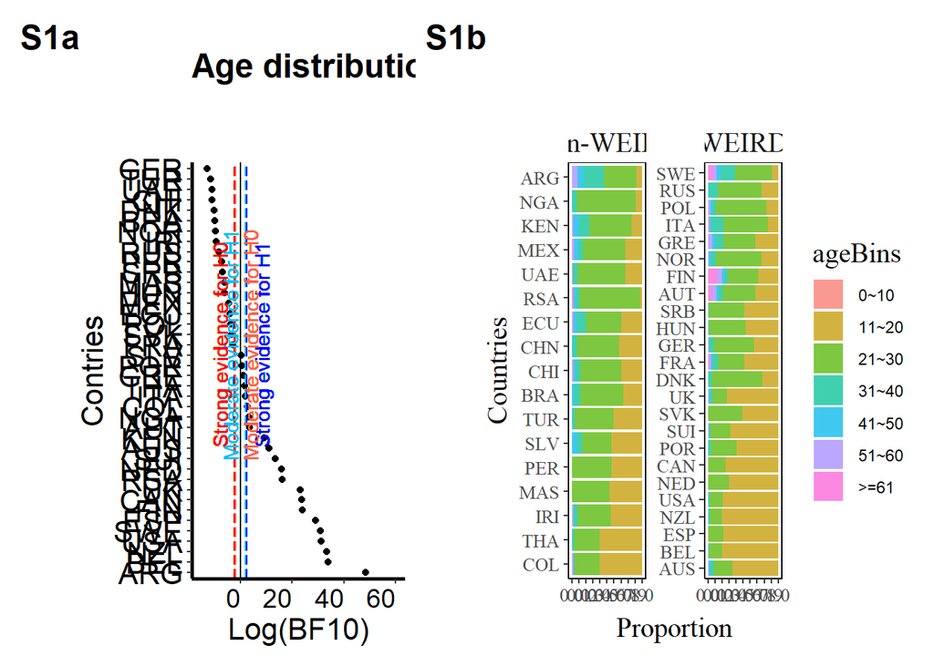

```r
df_PSA001_age_Jasp1_long <- Func_Age_Prop(df = df_PSA001_Age_valid_countryCode_sorted,
                                     break_names = c(0, 10.5, 20.5, 30.5, 40.5, 50.5, 60.5, Inf),
                                     label_names = c("0~10","11~20","21~30", "31~40", "41~50", "51~60", ">=61"),
                                     wider_form = FALSE) %>%
  dplyr::left_join(., df_regionCode, by = c("Countries" = "Jones_country")) %>%
  dplyr::mutate(Proportion = percent/100)

# Countries order for ploting age bins proprotions
df_PSA001_age_Jasp1_long_countries <- df_PSA001_age_Jasp1_long %>%
  dplyr::filter(ageBins == "0~10") %>%
  dplyr::arrange(Proportion) %>%
  dplyr::pull(Countries)

df_PSA001_age_Jasp1_long <- df_PSA001_age_Jasp1_long %>%
  dplyr::mutate(Countries = factor(Countries, levels = df_PSA001_age_Jasp1_long_countries))


S1b <- ggplot(df_PSA001_age_Jasp1_long, aes(x=Proportion, y=Countries, fill=ageBins)) +
  geom_col(alpha = .75)+
  labs(y="Countries") +
  scale_fill_discrete(label=c("0~10","11~20","21~30", "31~40", "41~50", "51~60", ">=61")) +
  theme_classic()+
  guides(y="axis_nested") +
  theme(legend.title = element_text(size = 15,family = "serif"),
        axis.title= element_text(size = 15,family = "serif"),
        axis.text = element_text(size = 10,family = "serif"),
        strip.text = element_text(size = 15,family = "serif"),
        strip.background = element_rect(fill = NA,color = NA),
        panel.border = element_rect(fill = NA,color = "black")) +
  scale_x_continuous(breaks = seq(0, 1, by = 0.1)) +
  facet_wrap(~ weird, scales = "free")
#S1b

S1a <- ggplot(BF_h3b_age_p_1, aes( x = `Log(BF10)_NonInform`, y = Contries)) +
  geom_point() +
  scale_color_grey() +
  xlim(-15, 60) +
  scale_y_discrete(limits=rev) +
  geom_vline(xintercept = c(log(1/10), log(1/6), 0, log(6), log(10)),
             colour = c("red", "tomato", "black", "deepskyblue","blue"),
             linetype=c("longdash", "longdash", "solid", "longdash","longdash")) +
  geom_text(aes(x=log(10), label="\nStrong evidence for H1", y = 23), colour="blue", alpha = 0.7,
            angle=90, text=element_text(size=10)) +
  geom_text(aes(x=log(6), label="Moderate evidence for H1\n", y = 23), colour="deepskyblue", alpha = 0.7,
            angle=90, text=element_text(size=10)) +
  geom_text(aes(x=log(1/6), label="\nModerate evidence for H0", y = 23), colour="tomato", alpha = 0.7,
            angle=90, text=element_text(size=10)) +
  geom_text(aes(x=log(1/10), label="Strong evidence for H0\n", y = 23), colour="red", alpha = 0.7,
            angle=90, text=element_text(size=10))  +
  ggtitle("Age distribution") +
  xlab("Log(BF10)")+
  theme_bw() +
        theme(panel.grid.major = element_blank(),
              panel.grid.minor = element_blank(),
              panel.background = element_blank(),
              panel.border = element_blank(),
              text = element_text(family='Times'),
              axis.text.x = element_text (size = 14, color = 'black',  hjust = 1),
              axis.text.y = element_text (size = 16, color = 'black'),
              plot.title = element_text(lineheight=.8, face="bold", size = 18, margin=margin(0,0,20,0)),
              axis.text = element_text (size = 16, color = 'black'),
              axis.title = element_text (size = 16),
              axis.title.x = element_text (size = 16),
              axis.title.y = element_text( size = 16),
              axis.line.x = element_line(color='black', size = 1),
              axis.line.y = element_line(color='black', size = 1))
#S1a
p_BF_supp <- S1a + S1b +
  plot_layout(tag_level = 'new') +
  plot_annotation(tag_levels =list(c("S1a","S1b")))  &
  theme(plot.tag = element_text(size = 18, face = "bold"))

ggsave("Fig4_withBF_supp.pdf", p_BF_supp, device = "pdf", width=18, height = 9)
p_BF_supp
```